# Forecast daily bike rental demand using time series models

Isha Gupta

2026-03-17

# About Data Analysis Report

This RMarkdown file contains the report of the data analysis done for the project on forecasting daily bike rental demand using time series models in R. It includes data exploration, summary statistics, time series visualization, smoothing techniques, decomposition, stationarity testing, and forecasting using ARIMA models.

The final report was completed on Tue Mar 17 17:39:53 2026.

**Data Description:**

This dataset contains the daily count of rental bike transactions between 2011 and 2012 in the Capital Bikeshare system along with weather and seasonal information.

**Data Source:**  
https://archive.ics.uci.edu/ml/datasets/bike+sharing+dataset

**Relevant Paper:**  
Fanaee-T, Hadi, and Gama, Joao. Event labeling combining ensemble detectors and background knowledge, Progress in Artificial Intelligence (2013).

# Task One: Load and Explore the Data

## Load data and install packages

```r
library(timetk)
library(tidyverse)
library(lubridate)
library(forecast)
library(tseries)
library(TTR)
```

## Load Dataset

```r
data("bike_sharing_daily")
bike_data <- bike_sharing_daily
head(bike_data)
```

```
## # A tibble: 6 × 16
##   instant dteday     season    yr  mnth holiday weekday workingday weathersit
##     <dbl> <date>      <dbl> <dbl> <dbl>   <dbl>   <dbl>      <dbl>      <dbl>
## 1       1 2011-01-01      1     0     1       0       6          0          2
## 2       2 2011-01-02      1     0     1       0       0          0          2
## 3       3 2011-01-03      1     0     1       0       1          1          1
## 4       4 2011-01-04      1     0     1       0       2          1          1
## 5       5 2011-01-05      1     0     1       0       3          1          1
## 6       6 2011-01-06      1     0     1       0       4          1          1
## # ℹ 7 more variables: temp <dbl>, atemp <dbl>, hum <dbl>, windspeed <dbl>,
## #   casual <dbl>, registered <dbl>, cnt <dbl>
```

```r
summary(bike_data)
```

```
##     instant          dteday               season            yr
##  Min.   :  1.0   Min.   :2011-01-01   Min.   :1.000   Min.   :0.0000
##  1st Qu.:183.5   1st Qu.:2011-07-02   1st Qu.:2.000   1st Qu.:0.0000
##  Median :366.0   Median :2012-01-01   Median :3.000   Median :1.0000
##  Mean   :366.0   Mean   :2012-01-01   Mean   :2.497   Mean   :0.5007
##  3rd Qu.:548.5   3rd Qu.:2012-07-01   3rd Qu.:3.000   3rd Qu.:1.0000
##  Max.   :731.0   Max.   :2012-12-31   Max.   :4.000   Max.   :1.0000
##       mnth          holiday           weekday        workingday
##  Min.   : 1.00   Min.   :0.00000   Min.   :0.000   Min.   :0.000
##  1st Qu.: 4.00   1st Qu.:0.00000   1st Qu.:1.000   1st Qu.:0.000
##  Median : 7.00   Median :0.00000   Median :3.000   Median :1.000
##  Mean   : 6.52   Mean   :0.02873   Mean   :2.997   Mean   :0.684
##  3rd Qu.:10.00   3rd Qu.:0.00000   3rd Qu.:5.000   3rd Qu.:1.000
##  Max.   :12.00   Max.   :1.00000   Max.   :6.000   Max.   :1.000
##    weathersit         temp             atemp              hum
##  Min.   :1.000   Min.   :0.05913   Min.   :0.07907   Min.   :0.0000
##  1st Qu.:1.000   1st Qu.:0.33708   1st Qu.:0.33784   1st Qu.:0.5200
##  Median :1.000   Median :0.49833   Median :0.48673   Median :0.6267
##  Mean   :1.395   Mean   :0.49538   Mean   :0.47435   Mean   :0.6279
##  3rd Qu.:2.000   3rd Qu.:0.65542   3rd Qu.:0.60860   3rd Qu.:0.7302
##  Max.   :3.000   Max.   :0.86167   Max.   :0.84090   Max.   :0.9725
##    windspeed           casual         registered        cnt
##  Min.   :0.02239   Min.   :   2.0   Min.   :  20   Min.   :  22
##  1st Qu.:0.13495   1st Qu.: 315.5   1st Qu.:2497   1st Qu.:3152
##  Median :0.18097   Median : 713.0   Median :3662   Median :4548
##  Mean   :0.19049   Mean   : 848.2   Mean   :3656   Mean   :4504
##  3rd Qu.:0.23321   3rd Qu.:1096.0   3rd Qu.:4776   3rd Qu.:5956
##  Max.   :0.50746   Max.   :3410.0   Max.   :6946   Max.   :8714
```

```r
names(bike_data)
```

```
##  [1] "instant"    "dteday"     "season"     "yr"         "mnth"
##  [6] "holiday"    "weekday"    "workingday" "weathersit" "temp"
## [11] "atemp"      "hum"        "windspeed"  "casual"     "registered"
## [16] "cnt"
```

```r
data("bike_sharing_daily")

bike_data <- bike_sharing_daily

head(bike_data)
```

```
## # A tibble: 6 × 16
##   instant dteday     season    yr  mnth holiday weekday workingday weathersit
##     <dbl> <date>      <dbl> <dbl> <dbl>   <dbl>   <dbl>      <dbl>      <dbl>
## 1       1 2011-01-01      1     0     1       0       6          0          2
## 2       2 2011-01-02      1     0     1       0       0          0          2
## 3       3 2011-01-03      1     0     1       0       1          1          1
## 4       4 2011-01-04      1     0     1       0       2          1          1
## 5       5 2011-01-05      1     0     1       0       3          1          1
## 6       6 2011-01-06      1     0     1       0       4          1          1
## # ℹ 7 more variables: temp <dbl>, atemp <dbl>, hum <dbl>, windspeed <dbl>,
## #   casual <dbl>, registered <dbl>, cnt <dbl>
```

```r
summary(bike_data)
```

```
##     instant          dteday               season            yr
##  Min.   :  1.0   Min.   :2011-01-01   Min.   :1.000   Min.   :0.0000
##  1st Qu.:183.5   1st Qu.:2011-07-02   1st Qu.:2.000   1st Qu.:0.0000
##  Median :366.0   Median :2012-01-01   Median :3.000   Median :1.0000
##  Mean   :366.0   Mean   :2012-01-01   Mean   :2.497   Mean   :0.5007
##  3rd Qu.:548.5   3rd Qu.:2012-07-01   3rd Qu.:3.000   3rd Qu.:1.0000
##  Max.   :731.0   Max.   :2012-12-31   Max.   :4.000   Max.   :1.0000
##       mnth          holiday           weekday        workingday
##  Min.   : 1.00   Min.   :0.00000   Min.   :0.000   Min.   :0.000
##  1st Qu.: 4.00   1st Qu.:0.00000   1st Qu.:1.000   1st Qu.:0.000
##  Median : 7.00   Median :0.00000   Median :3.000   Median :1.000
##  Mean   : 6.52   Mean   :0.02873   Mean   :2.997   Mean   :0.684
##  3rd Qu.:10.00   3rd Qu.:0.00000   3rd Qu.:5.000   3rd Qu.:1.000
##  Max.   :12.00   Max.   :1.00000   Max.   :6.000   Max.   :1.000
##    weathersit         temp             atemp              hum
##  Min.   :1.000   Min.   :0.05913   Min.   :0.07907   Min.   :0.0000
##  1st Qu.:1.000   1st Qu.:0.33708   1st Qu.:0.33784   1st Qu.:0.5200
##  Median :1.000   Median :0.49833   Median :0.48673   Median :0.6267
##  Mean   :1.395   Mean   :0.49538   Mean   :0.47435   Mean   :0.6279
##  3rd Qu.:2.000   3rd Qu.:0.65542   3rd Qu.:0.60860   3rd Qu.:0.7302
##  Max.   :3.000   Max.   :0.86167   Max.   :0.84090   Max.   :0.9725
##    windspeed           casual         registered        cnt
##  Min.   :0.02239   Min.   :   2.0   Min.   :  20   Min.   :  22
##  1st Qu.:0.13495   1st Qu.: 315.5   1st Qu.:2497   1st Qu.:3152
##  Median :0.18097   Median : 713.0   Median :3662   Median :4548
##  Mean   :0.19049   Mean   : 848.2   Mean   :3656   Mean   :4504
##  3rd Qu.:0.23321   3rd Qu.:1096.0   3rd Qu.:4776   3rd Qu.:5956
##  Max.   :0.50746   Max.   :3410.0   Max.   :6946   Max.   :8714
```

```r
str(bike_data)
```

```
## spc_tbl_ [731 × 16] (S3: spec_tbl_df/tbl_df/tbl/data.frame)
##  $ instant   : num [1:731] 1 2 3 4 5 6 7 8 9 10 ...
##  $ dteday    : Date[1:731], format: "2011-01-01" "2011-01-02" ...
##  $ season    : num [1:731] 1 1 1 1 1 1 1 1 1 1 ...
##  $ yr        : num [1:731] 0 0 0 0 0 0 0 0 0 0 ...
##  $ mnth      : num [1:731] 1 1 1 1 1 1 1 1 1 1 ...
##  $ holiday   : num [1:731] 0 0 0 0 0 0 0 0 0 0 ...
##  $ weekday   : num [1:731] 6 0 1 2 3 4 5 6 0 1 ...
##  $ workingday: num [1:731] 0 0 1 1 1 1 1 0 0 1 ...
##  $ weathersit: num [1:731] 2 2 1 1 1 1 2 2 1 1 ...
##  $ temp      : num [1:731] 0.344 0.363 0.196 0.2 0.227 ...
##  $ atemp     : num [1:731] 0.364 0.354 0.189 0.212 0.229 ...
##  $ hum       : num [1:731] 0.806 0.696 0.437 0.59 0.437 ...
##  $ windspeed : num [1:731] 0.16 0.249 0.248 0.16 0.187 ...
##  $ casual    : num [1:731] 331 131 120 108 82 88 148 68 54 41 ...
##  $ registered: num [1:731] 654 670 1229 1454 1518 ...
##  $ cnt       : num [1:731] 985 801 1349 1562 1600 ...
##  - attr(*, "spec")=
##   .. cols(
##   ..   instant = col_double(),
##   ..   dteday = col_date(format = ""),
##   ..   season = col_double(),
##   ..   yr = col_double(),
##   ..   mnth = col_double(),
##   ..   holiday = col_double(),
##   ..   weekday = col_double(),
##   ..   workingday = col_double(),
##   ..   weathersit = col_double(),
##   ..   temp = col_double(),
##   ..   atemp = col_double(),
##   ..   hum = col_double(),
##   ..   windspeed = col_double(),
##   ..   casual = col_double(),
##   ..   registered = col_double(),
##   ..   cnt = col_double()
##   .. )
```

```r
cor(bike_data$temp, bike_data$cnt)
```

```
## [1] 0.627494
```

```r
cor(bike_data$atemp, bike_data$cnt)
```

```
## [1] 0.6310657
```

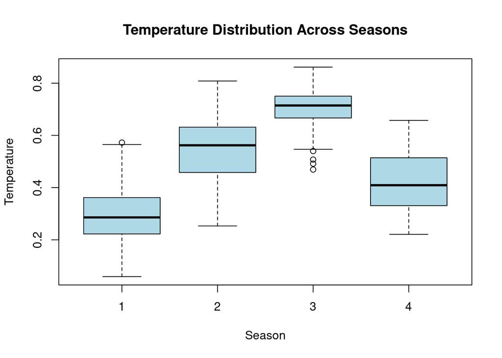

```r
boxplot(temp ~ season,
        data = bike_data,
        col="lightblue",
        main="Temperature Distribution Across Seasons",
        xlab="Season",
        ylab="Temperature")
```

```r
library(tidyverse)
library(lubridate)
```

```r
data("bike_sharing_daily")
bike_data <- bike_sharing_daily
```

```r
bike_data %>%
  mutate(month = lubridate::month(dteday, label = TRUE)) %>%
  group_by(month) %>%
  summarise(
    mean_temp = mean(temp),
    mean_humidity = mean(hum),
    mean_windspeed = mean(windspeed),
    mean_rentals = mean(cnt)
  )
```

```
## # A tibble: 12 × 5
##    month mean_temp mean_humidity mean_windspeed mean_rentals
##    <ord>     <dbl>         <dbl>          <dbl>        <dbl>
##  1 Jan       0.236         0.586          0.206        2176.
##  2 Feb       0.299         0.567          0.216        2655.
##  3 Mar       0.391         0.588          0.223        3692.
##  4 Apr       0.470         0.588          0.234        4485.
##  5 May       0.595         0.689          0.183        5350.
##  6 Jun       0.684         0.576          0.185        5772.
##  7 Jul       0.755         0.598          0.166        5564.
##  8 Aug       0.709         0.638          0.173        5664.
##  9 Sep       0.616         0.715          0.166        5767.
## 10 Oct       0.485         0.694          0.175        5199.
## 11 Nov       0.369         0.625          0.184        4247.
## 12 Dec       0.324         0.666          0.177        3404.
```

#Task two: Create Interactive Time Seies Plot

```r
bike_data %>%
  plot_time_series(
    dteday,
    cnt,
    .interactive = TRUE,
    .plotly_slider = TRUE,
    .title = "Daily Bike Rental Demand Over Time"
  )
```

[interactive chart not shown]

```r
bike_data %>%
  plot_seasonal_diagnostics(
    dteday,
    cnt
  )
```

[interactive chart not shown]

```r
bike_data %>%
  plot_anomaly_diagnostics(
    dteday,
    cnt
  )
```

```
## frequency = 7 observations per 1 week
```

```
## trend = 92 observations per 3 months
```

[interactive chart not shown]

#Task Three: Smooth Time Series Data

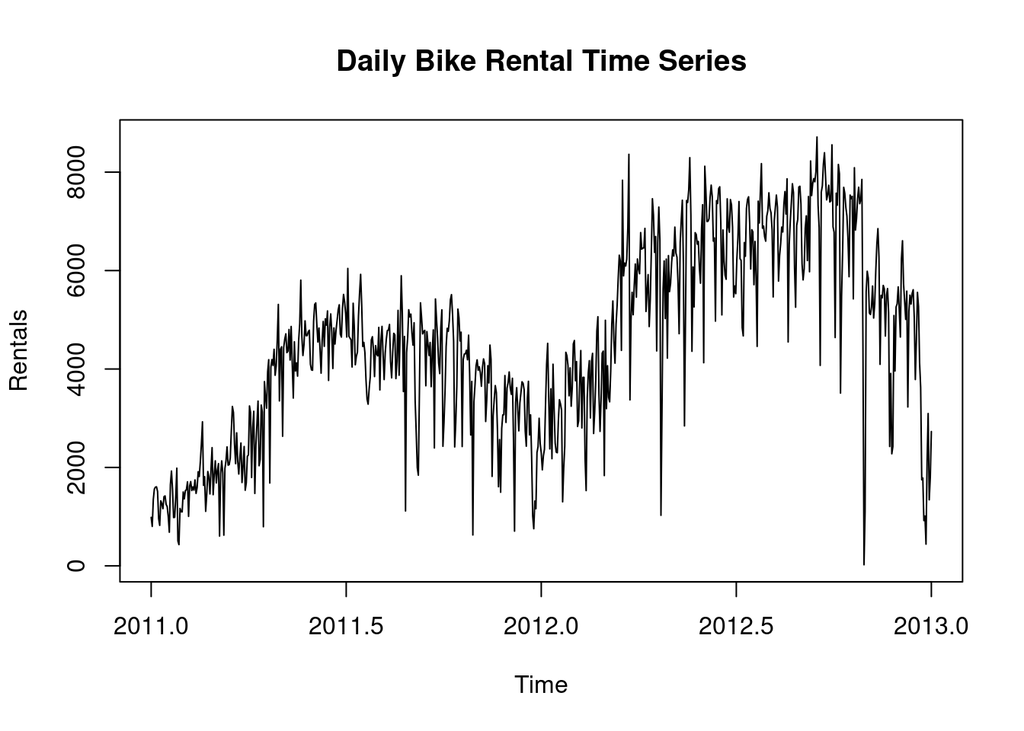

```r
ts_data <- ts(bike_data$cnt,
              frequency = 365,
              start = c(2011,1))

plot(ts_data,
     main="Daily Bike Rental Time Series",
     ylab="Rentals",
     xlab="Time")
```

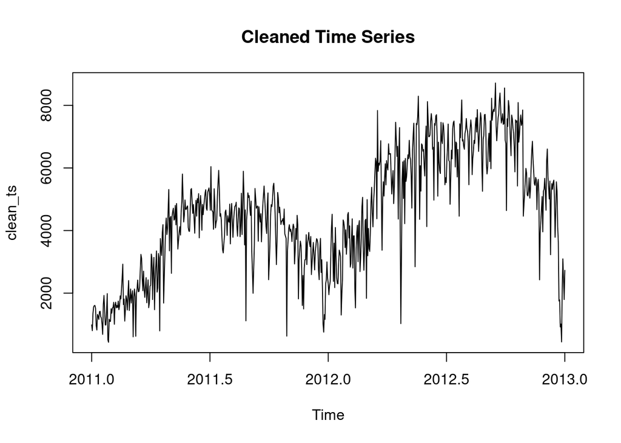

```r
clean_ts <- tsclean(ts_data)

plot(clean_ts,
     main="Cleaned Time Series")
```

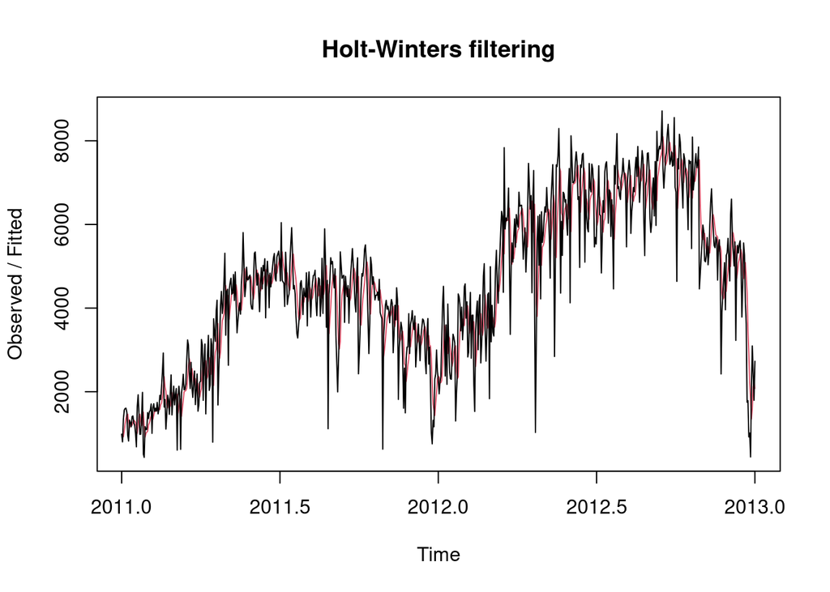

```r
ses_model <- HoltWinters(clean_ts, beta = FALSE, gamma = FALSE)

plot(ses_model)
```

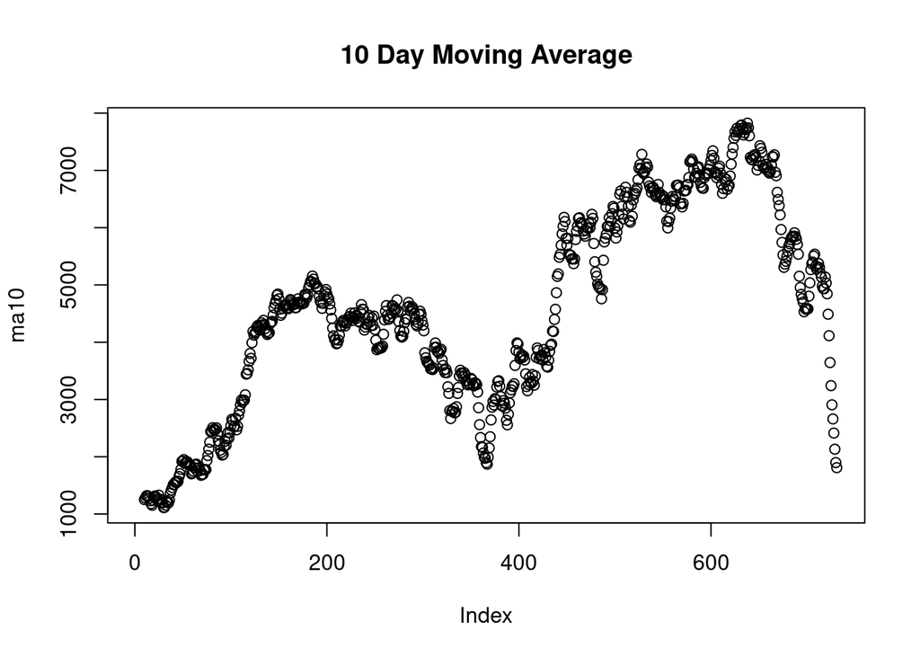

```r
ma10 <- SMA(clean_ts, n=10)

plot(ma10,
     main="10 Day Moving Average")
```

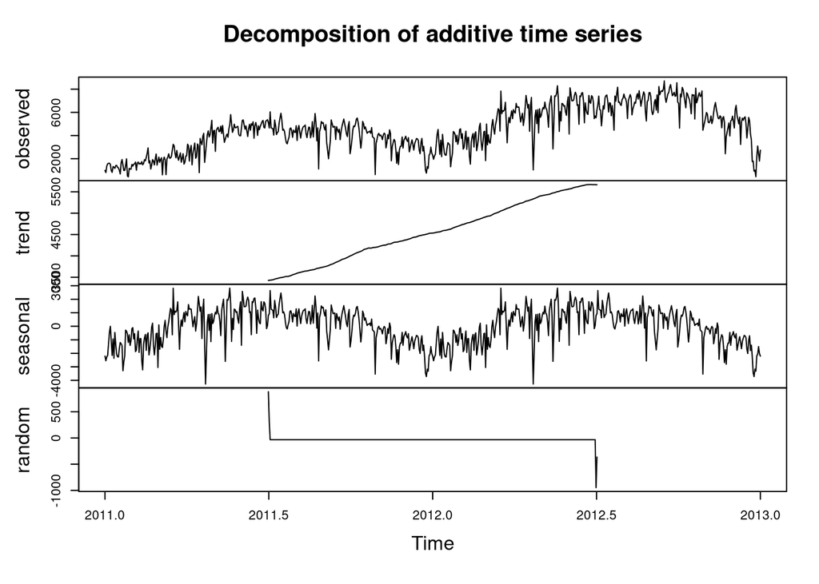

```r
decomp <- decompose(clean_ts)

plot(decomp)
```

```r
adf.test(clean_ts)
```

```
##
##  Augmented Dickey-Fuller Test
##
## data:  clean_ts
## Dickey-Fuller = -1.4435, Lag order = 9, p-value = 0.8138
## alternative hypothesis: stationary
```

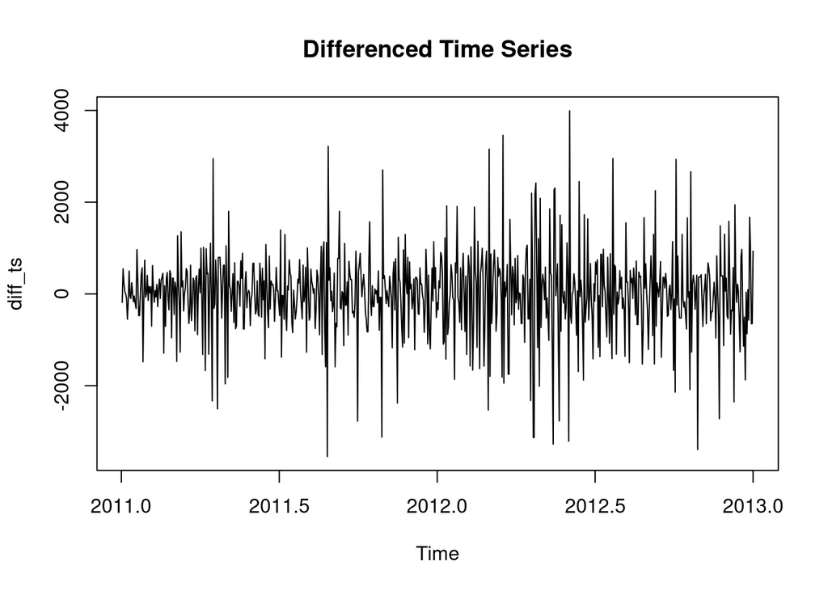

```r
diff_ts <- diff(clean_ts)

plot(diff_ts,
     main="Differenced Time Series")
```

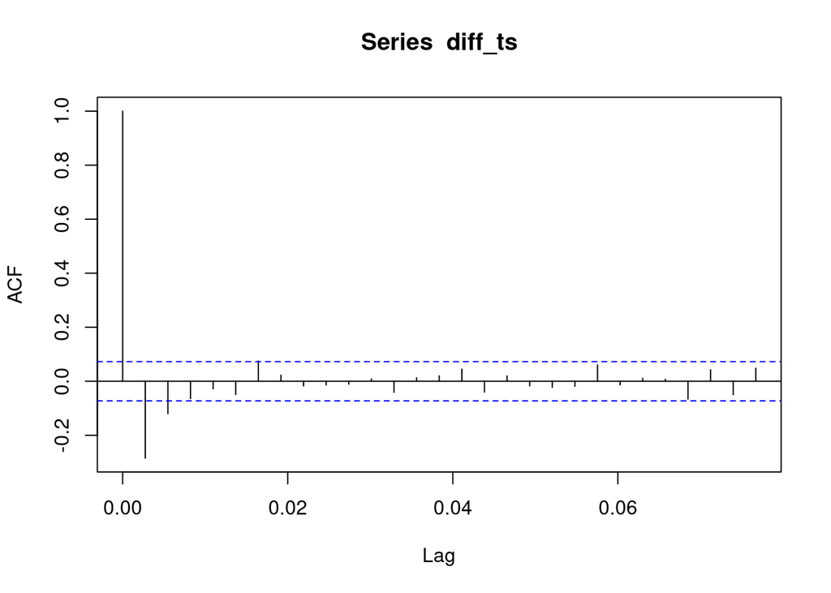

```r
acf(diff_ts)
```

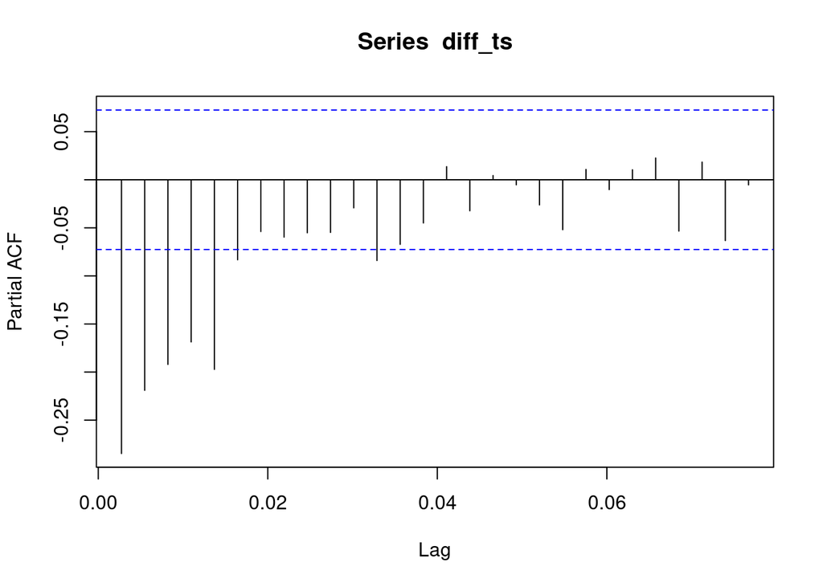

```r
pacf(diff_ts)
```

```r
clean_ts
```

[output not shown]

[output cut: 81 more lines]

```r
auto_model <- auto.arima(clean_ts, seasonal = FALSE)

summary(auto_model)
```

```
## Series: clean_ts
## ARIMA(1,1,1)
##
## Coefficients:
##          ar1      ma1
##       0.3692  -0.8751
## s.e.  0.0437   0.0213
##
## sigma^2 = 663543:  log likelihood = -5928.18
## AIC=11862.37   AICc=11862.4   BIC=11876.15
##
## Training set error measures:
##                    ME     RMSE      MAE       MPE     MAPE      MASE       ACF1
## Training set 11.13247 812.9082 588.1202 -6.429274 19.42943 0.2582884 0.01109983
```

```r
manual_model <- arima(clean_ts, order=c(2,1,2))

summary(manual_model)
```

```
##
## Call:
## arima(x = clean_ts, order = c(2, 1, 2))
##
## Coefficients:
##          ar1      ar2      ma1     ma2
##       0.8975  -0.2461  -1.3898  0.4637
## s.e.  0.4065   0.1443   0.4101  0.3562
##
## sigma^2 estimated as 659903:  log likelihood = -5927.19,  aic = 11864.38
##
## Training set error measures:
##                    ME     RMSE     MAE       MPE    MAPE     MASE         ACF1
## Training set 9.057166 811.7884 583.976 -6.507784 19.3814 0.887764 -0.004821705
```

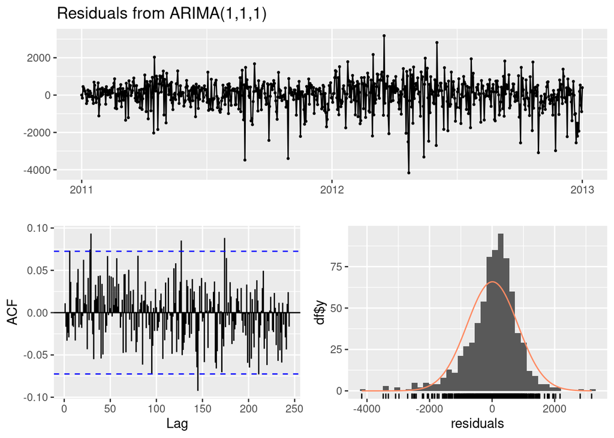

```
##
##  Ljung-Box test
##
## data:  Residuals from ARIMA(1,1,1)
## Q* = 142.67, df = 144, p-value = 0.5156
##
## Model df: 2.   Total lags used: 146
```

```r
checkresiduals(auto_model)
```

```r
shapiro.test(residuals(auto_model))
```

```
##
##  Shapiro-Wilk normality test
##
## data:  residuals(auto_model)
## W = 0.94187, p-value = 2.596e-16
```

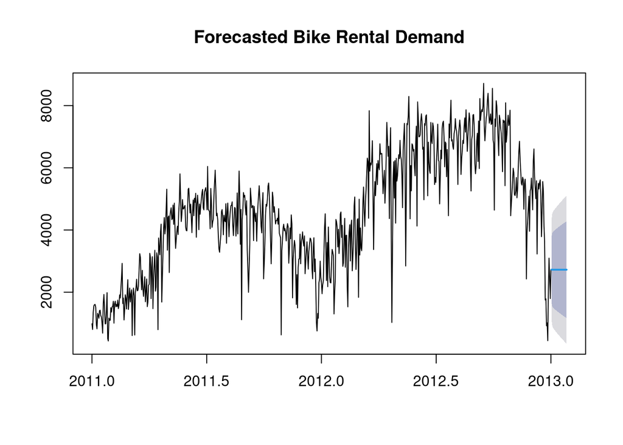

```r
forecast_auto <- forecast(auto_model, h=25)

plot(forecast_auto,
     main="Forecasted Bike Rental Demand")
```

# Task Six: Findings and Conclusions

## Key Insights

- Bike rental demand shows strong seasonal behavior throughout the year.
- Temperature has a positive relationship with bike rental demand. Higher temperatures tend to increase bike usage.
- Rental demand is highest during warmer seasons such as summer, while demand decreases during colder months.
- Registered users contribute significantly more rentals compared to casual users, indicating consistent usage by regular commuters.

## Business Recommendations

Based on the results of this analysis, the bike rental company can consider the following strategies:

- Increase bike availability during warmer months when rental demand is high.
- Reduce the number of bikes available during colder seasons to optimize operational costs.
- Use demand forecasting to implement dynamic pricing strategies during peak demand periods.
- Expand bike stations in high demand areas to improve service availability and customer satisfaction.

## Limitations

- The dataset only contains two years of data, which may limit the long-term forecasting accuracy.
- External factors such as holidays, special events, and economic conditions were not included in this analysis.
- Weather prediction uncertainty may affect the accuracy of future demand forecasts.

## Future Work

Future improvements to this analysis could include:

- Incorporating additional weather variables such as precipitation and visibility.
- Applying machine learning forecasting models such as Random Forest or Gradient Boosting.
- Analyzing hourly bike rental demand to obtain more detailed insights into user behavior.

## Conclusion

Time series analysis provides valuable insights into bike rental demand patterns. By applying ARIMA forecasting models, bike rental companies can improve operational planning, optimize fleet allocation, and enhance pricing strategies. These insights can help businesses better manage resources and improve customer service.